# Estudio retenciones en Valencia

Vamos a estudiar datos históricos de retenciones en Valencia # Carga de Datos Cargamos Datos y vemos qué pinta tienen,

```r
library(plyr)
load("totr.Rdata")

dat<-tot

head(tot)
```

```
##    any mes dia hora minut  id estat
## 1 2015   2  10    0     0 168     0
## 2 2015   2  10    0     0 180     0
## 3 2015   2  10    0     0 182     0
## 4 2015   2  10    0     0
## 5 2015   2  10    0     0 275     0
## 6 2015   2  10    0     0 277     5
##                                             carrer
## 1                                 NICASIO BENLLOCH
## 2        TOMAS SALA (DE CARTEROS A GASPAR AGUILAR)
## 3           SAGUNTO (DE PLAZA STA. MÓNICA A RUAYA)
## 4
## 5 PUENTE DEL ASSUT DE L'OR HACIA ANTONIO FERRANDIS
## 6                 PASO INFERIOR CATALUÑA DE SALIDA
```

# Formateo de Datos

Vamos a formatear los datos

```r
fecha<-paste(as.character(dat[,1]),as.character(dat[,2]),as.character(dat[,3]),sep="-")
diasem<-as.POSIXlt(as.Date(fecha))$wday
## añadimos fecha y diasem
dat$fecha<-fecha
dat$diasem<-diasem

dat$diasem <- as.factor(dat$diasem)
diasemlabel=revalue(dat$diasem, c("0"="Domingo","1"="Lunes","2"="Martes","3"="Miercoles","4"="Jueves","5"="Viernes","6"="Sabado"))
dat$diasemlabel<-diasemlabel
#Ver fecha maxima y minima
max(fecha)
```

```
## [1] "2015-4-9"
```

```r
min(fecha)
```

```
## [1] "2015-2-10"
```

```r
filt<-subset(dat,id==168 & fecha==as.POSIXlt("2015-3-3"))
print(filt)
```

```
##          any mes dia hora minut  id estat           carrer    fecha diasem
## 1304911 2015   3   3    0    15 168     0 NICASIO BENLLOCH 2015-3-3      2
## 1315075 2015   3   3    0    30 168     0 NICASIO BENLLOCH 2015-3-3      2
## 1317616 2015   3   3    0    45 168     0 NICASIO BENLLOCH 2015-3-3      2
## 1323424 2015   3   3   10     0 168     0 NICASIO BENLLOCH 2015-3-3      2
## 1323787 2015   3   3   10    15 168     0 NICASIO BENLLOCH 2015-3-3      2
## 1324513 2015   3   3   10    30 168     0 NICASIO BENLLOCH 2015-3-3      2
## 1325239 2015   3   3   10    45 168     0 NICASIO BENLLOCH 2015-3-3      2
## 1325965 2015   3   3    1     0 168     0 NICASIO BENLLOCH 2015-3-3      2
## 1327465 2015   3   3   11     0 168     0 NICASIO BENLLOCH 2015-3-3      2
## 1328917 2015   3   3   11    15 168     0 NICASIO BENLLOCH 2015-3-3      2
## 1330732 2015   3   3   11    30 168     0 NICASIO BENLLOCH 2015-3-3      2
## 1333636 2015   3   3   11    45 168     0 NICASIO BENLLOCH 2015-3-3      2
## 1335403 2015   3   3    1    15 168     0 NICASIO BENLLOCH 2015-3-3      2
## 1341259 2015   3   3   12     0 168     0 NICASIO BENLLOCH 2015-3-3      2
```

[output cut: 157 more lines]

```r
dim(filt)
```

```
## [1] 85 11
```

De acuerdo a la web Estados 0. Fluido 1. Denso 2. Congestionado 3. Cortado

Si hay otros estados los ponemos a 4 desconocido. Y lo trasnformamos en factor

```r
sum(is.na(dat$estat))
```

```
## [1] 0
```

```r
table(dat$estat)
```

```
##
##               0       1       2       3       4       5       6       7
##    1623 1728916    3005     795   14434    3088  150527     277     112
##       8       9
##     897     261
```

```r
dat[which(dat$estat>3),"estat"]<-4
table(dat$estat)
```

```
##
##               0       1       2       3       4
##    1623 1728916    3005     795   14434  155162
```

```r
#festat guarda estat como factor
dat$festat = factor(dat$estat, levels = 0:4, labels = c("fluido", "denso","Congestionado","Cortado","Desconocido"))
table(dat$festat)
```

```
##
##        fluido         denso Congestionado       Cortado   Desconocido
##       1728916          3005           795         14434        155162
```

```r
#atasco es un booleano, con NA para desconocidos
atasco = rep(0,length(dat$estat))
atasco [which(dat$estat==1)]<-1
atasco [which(dat$estat==2)]<-1
atasco [which(dat$estat>3)]<-NA
dat$atasco<-atasco
table(dat$atasco)
```

```
##
##       0       1
## 1744973    3800
```

```r
#eliminamos los registros con NA en atasco
dat<-subset(dat,is.na(atasco)==FALSE)
```

# Ejercicios

1. ¿Cuál fue el peor día ?(día con más congestiones). Se puede utilizar Date$yday
2. ¿Cuál es el peor tramo? (Tramo con más congestiones).
3. ¿Cuál es peor y el mejor día de la semana? . Se puede utilizar Date$wday
4. ¿Las fallas incremetan las congestiones?. Considerar Fallas del 16 al 19 de marzo (incluidos)

# Resolución de ejercicios

# 1. ¿Cuál fue el peor día ?(día con más congestiones). Se puede utilizar Date$yday

En la variable fecha tenemos el dia y en la variable atasco tenemos las congestiones. Sabiendo esto solo tendremos que agrupar los atascos por fecha con un by. Le hacemos un sum para que sume los atascos por día.

```r
congs_dia<-by(dat["atasco"],dat$fecha,sum)
max_atasc_fecha_dia=which(congs_dia==max(congs_dia))
congs_dia[3]
```

```
## 2015-2-12
##       327
```

Como podemos ver el día con más atascos es el día 2015-2-12 con una puntuación de congestión de 327.

# 2. ¿Cuál es el peor tramo? (Tramo con más congestiones).

```r
congs_carrer<-by(dat["atasco"],dat$carrer,sum)
max_atasc_fecha_carrer=which(congs_carrer==max(congs_carrer))
congs_carrer[240]
```

```
## PERIS Y VALERO HACIA AUSIAS MARCH
##                               169
```

Como podemos ver el peor tramo es PERIS Y VALERO HACIA AUSIAS MARCH con una puntiación de congestión de 169

# 3. ¿Cuál es peor y el mejor día de la semana? . Se puede utilizar Date$wday

```r
congs_diasem<-by(dat["atasco"],dat$diasemlabel,sum)
max_atasc_fecha_diasem<-which(congs_diasem==max(congs_diasem))
min_atasc_fecha_diasem<-which(congs_diasem==min(congs_diasem))
print('Día con más congestiones')
```

```
## [1] "Día con más congestiones"
```

```r
congs_diasem[5]
```

```
## Jueves
##    776
```

```r
print('Día con menos congestiones')
```

```
## [1] "Día con menos congestiones"
```

```r
congs_diasem[1]
```

```
## Domingo
##     132
```

Como podemos observar el día con más congestiones son los Jueves con un sumatorio de congestiones de 776. En cambio podemos observar que los domingos el tráfico es mucho más fluido teniendo tan solo un sumatorio de congestiones de 132.

# 4. ¿Las fallas incremetan las congestiones?. Considerar Fallas del 16 al 19 de marzo (incluidos)

Este problema lo vamos a intentar abordar mediante una representación gráfica.

Primero de todo extraemos un subset de los días de fallas

```r
datsubfallas=subset(dat,(dia==16 | dia==17 | dia==18 | dia==19) & mes==3)
```

Seguidamente extraemos un subset de los días de fallas en otro mes que no son fallas

```r
datsubtotal=subset(dat,(dia==16 | dia==17 | dia==18 | dia==19) & mes!=3)
```

Curiosamente en 2015 los días 16,17,18,19 coinciden en lunes,martes,miercoles y jueves en los dos meses por lo que no tendremos en cuenta el factor de en qué día de la semana nos encontramos.

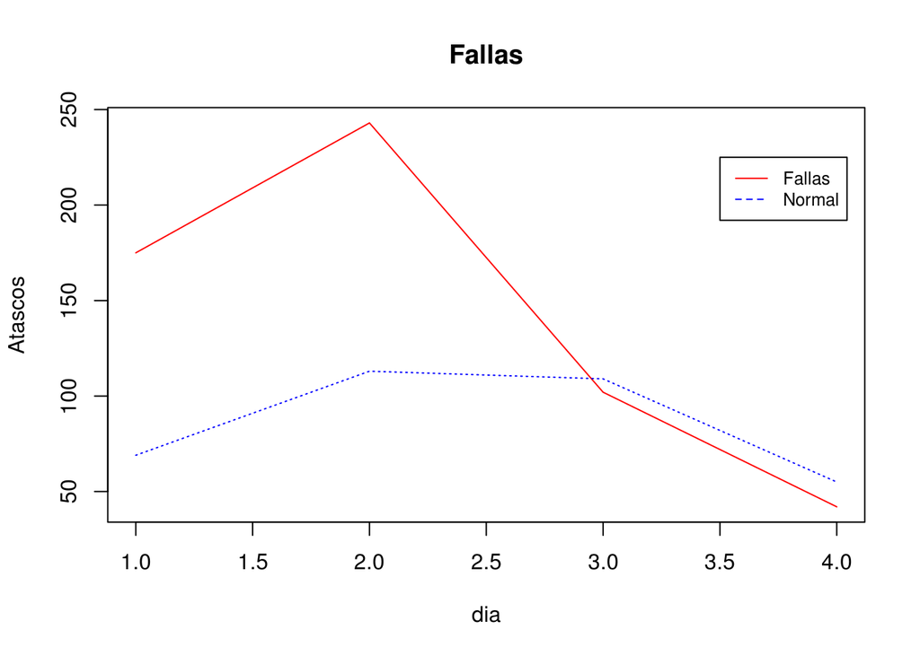

```r
diasfallas<-by(datsubfallas[,c("atasco")],datsubfallas$dia,sum)
diastotal<-by(datsubtotal[,c("atasco")],datsubtotal$dia,sum)
plot(diasfallas,lty=1,type="l", ylab="Atascos", xlab="dia",main="Fallas",col="red")
lines(diastotal,col="blue",lty=3)
legend(3.5, 225, legend=c("Fallas", "Normal"),col=c("red", "blue"), lty=1:3, cex=0.8)
```